# Applied exercises

# Applied

```r
library(ISLR)
library(MASS)
mod1 <- lm(mpg ~ horsepower, Auto)
summary(mod1)
```

```
Call:
lm(formula = mpg ~ horsepower, data = Auto)

Residuals:
     Min       1Q   Median       3Q      Max
-13.5710  -3.2592  -0.3435   2.7630  16.9240

Coefficients:
             Estimate Std. Error t value Pr(>|t|)
(Intercept) 39.935861   0.717499   55.66   <2e-16 ***
horsepower  -0.157845   0.006446  -24.49   <2e-16 ***
---
Signif. codes:  0 ‘***’ 0.001 ‘**’ 0.01 ‘*’ 0.05 ‘.’ 0.1 ‘ ’ 1

Residual standard error: 4.906 on 390 degrees of freedom
Multiple R-squared:  0.6059,    Adjusted R-squared:  0.6049
F-statistic: 599.7 on 1 and 390 DF,  p-value: < 2.2e-16
```

1. There is a significant relationship. That is, the relationship is different from 0.
2. For a one unit increase in horsepower the expected miles per gallon decreases by about 0.15. In addition, the R squared is of 60% suggesting that the horsepower explains mpg quite well.
3. negative

```r
predict(mod1, newdata = data.frame(horsepower = 98))
```

```
       1
24.46708
```

```r
# 24.46 mpg
# prediction and confidence interval
upper <- summary(mod1)$coef[, 1] + 1.96 * summary(mod1)$coef[, 2]
lower <- summary(mod1)$coef[, 1] - 1.96 * summary(mod1)$coef[, 2]
cbind(lower, upper)
```

```
                 lower      upper
(Intercept) 38.5295637 41.3421584
horsepower  -0.1704779 -0.1452116
```

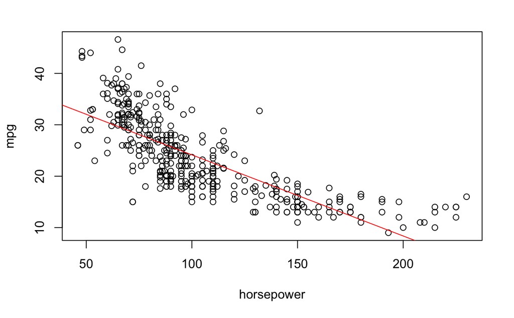

```r
with(Auto, plot(mpg ~ horsepower)); abline(mod1, col = "red")
```

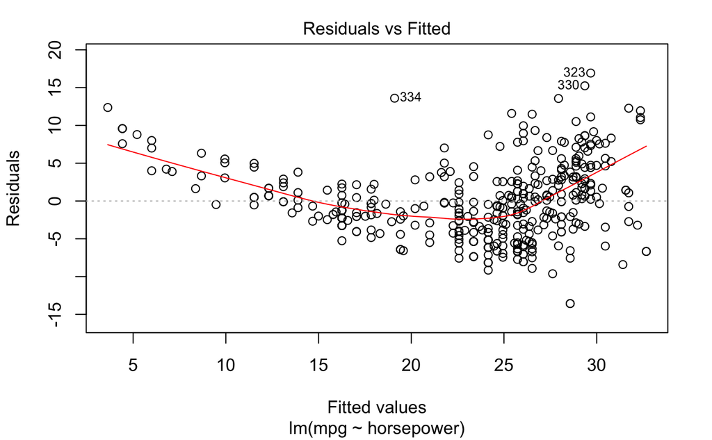

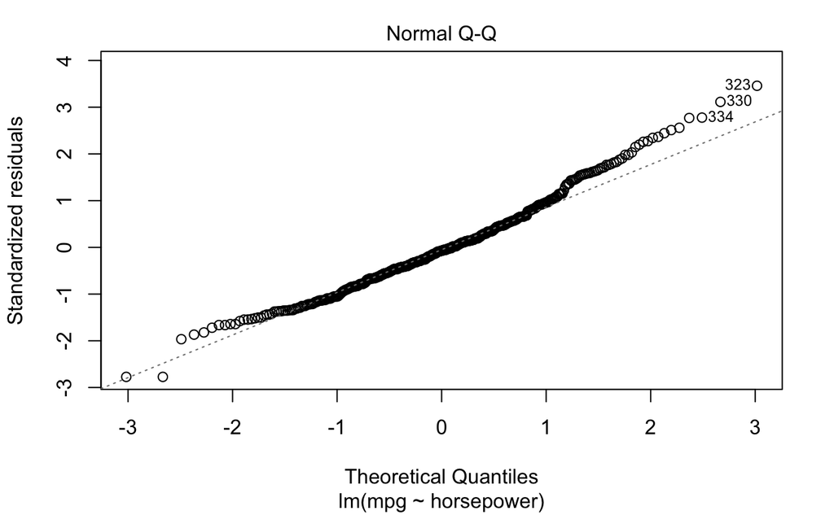

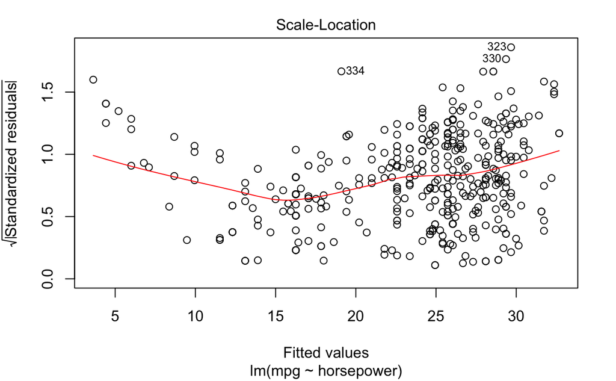

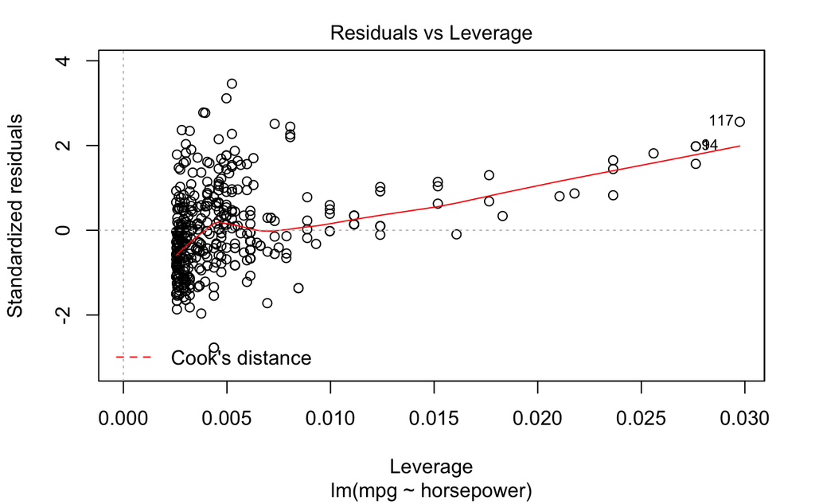

```r
plot(mod1)
```

Only two significant outliers, perhaps rerunning without those two outliers would be informative. The residuals are not entirely normally distributed but nothing really dramatic. The most worrisome thing is the residuals vs fitted values as there seems to be a clearn pattern. As fitted values increase the residual decrease. But after a certain threshold it starts to increase.

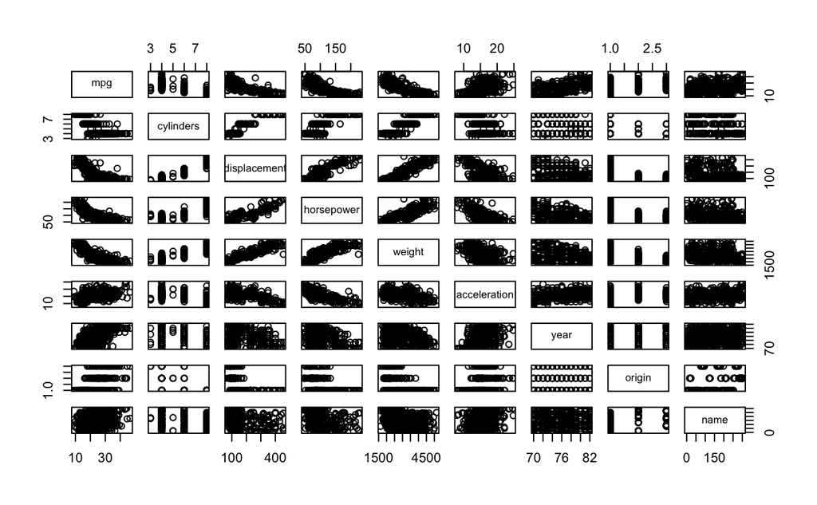

```r
plot(Auto)
```

```r
cor(Auto[!(names(Auto) %in% "name")])
```

```
                    mpg  cylinders displacement horsepower     weight acceleration       year     origin
mpg           1.0000000 -0.7776175   -0.8051269 -0.7784268 -0.8322442    0.4233285  0.5805410  0.5652088
cylinders    -0.7776175  1.0000000    0.9508233  0.8429834  0.8975273   -0.5046834 -0.3456474 -0.5689316
displacement -0.8051269  0.9508233    1.0000000  0.8972570  0.9329944   -0.5438005 -0.3698552 -0.6145351
horsepower   -0.7784268  0.8429834    0.8972570  1.0000000  0.8645377   -0.6891955 -0.4163615 -0.4551715
weight       -0.8322442  0.8975273    0.9329944  0.8645377  1.0000000   -0.4168392 -0.3091199 -0.5850054
acceleration  0.4233285 -0.5046834   -0.5438005 -0.6891955 -0.4168392    1.0000000  0.2903161  0.2127458
year          0.5805410 -0.3456474   -0.3698552 -0.4163615 -0.3091199    0.2903161  1.0000000  0.1815277
origin        0.5652088 -0.5689316   -0.6145351 -0.4551715 -0.5850054    0.2127458  0.1815277  1.0000000
```

```r
mod2 <- lm(mpg ~ . -name, Auto)
summary(mod2)
```

```
Call:
lm(formula = mpg ~ . - name, data = Auto)

Residuals:
    Min      1Q  Median      3Q     Max
-9.5903 -2.1565 -0.1169  1.8690 13.0604

Coefficients:
               Estimate Std. Error t value Pr(>|t|)
(Intercept)  -17.218435   4.644294  -3.707  0.00024 ***
cylinders     -0.493376   0.323282  -1.526  0.12780
displacement   0.019896   0.007515   2.647  0.00844 **
horsepower    -0.016951   0.013787  -1.230  0.21963
weight        -0.006474   0.000652  -9.929  < 2e-16 ***
acceleration   0.080576   0.098845   0.815  0.41548
year           0.750773   0.050973  14.729  < 2e-16 ***
origin         1.426141   0.278136   5.127 4.67e-07 ***
---
Signif. codes:  0 ‘***’ 0.001 ‘**’ 0.01 ‘*’ 0.05 ‘.’ 0.1 ‘ ’ 1

Residual standard error: 3.328 on 384 degrees of freedom
Multiple R-squared:  0.8215,    Adjusted R-squared:  0.8182
F-statistic: 252.4 on 7 and 384 DF,  p-value: < 2.2e-16
```

1. Yes as the F statistic is significant suggesting that At least ONE predictord is significantly related to mpg. Some predictors, however, don’t have a significant relationship while others do.
2. `displacement`, `weight`, `year` and `origin`.
3. That as the years increase, the mpg is increasing by about 0.75.

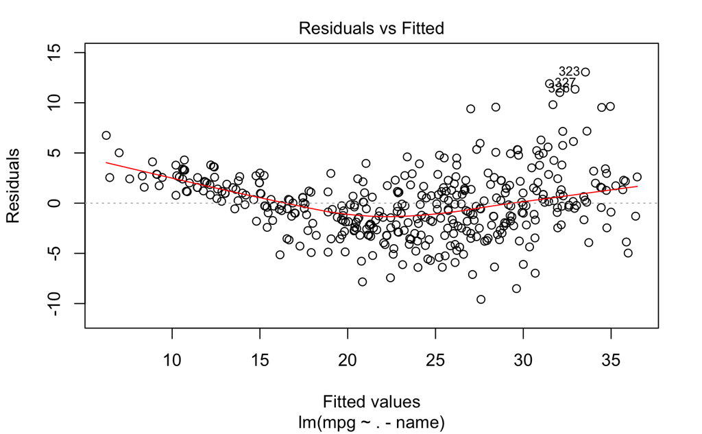

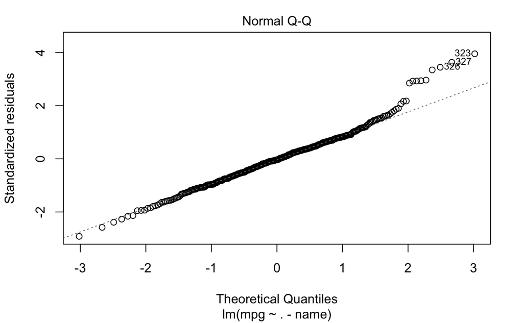

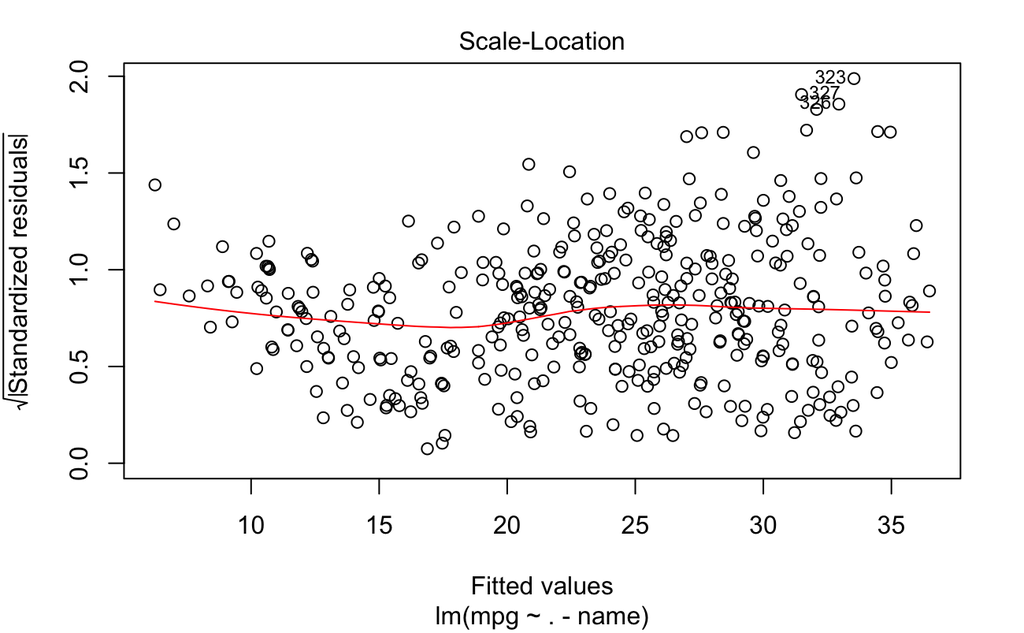

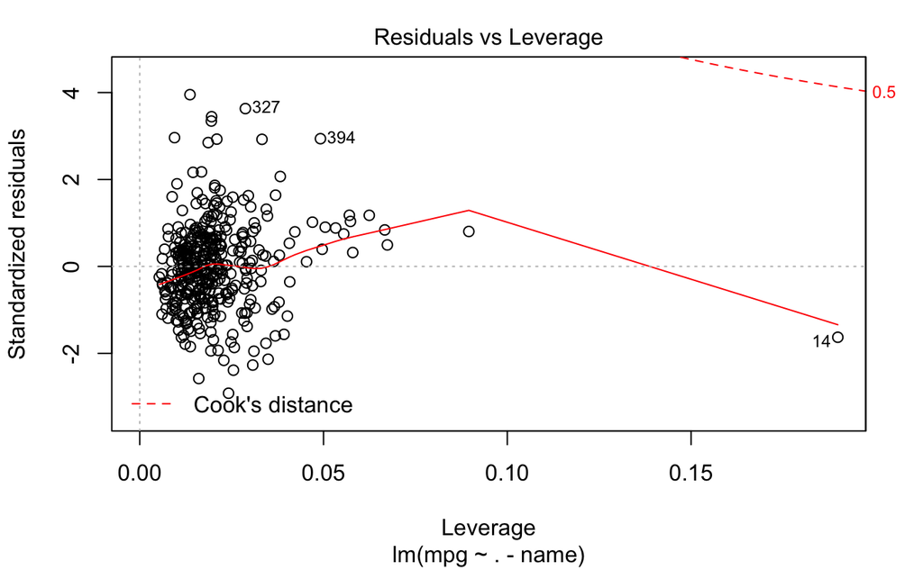

```r
plot(mod2)
```

The outlier plot suggests there is an outlier present, namely row 14, and its leverage is quite high. The residuals vs fitted is less severe than as before, but still it shows a pattern that as fitted values increase residuals become more dispersed. The residuals seem to be more normal than before.

```r
summary(lm(mpg ~ origin*cylinders + year*weight, Auto))
```

```
Call:
lm(formula = mpg ~ origin * cylinders + year * weight, data = Auto)

Residuals:
    Min      1Q  Median      3Q     Max
-9.1346 -1.8909 -0.0982  1.5958 12.2016

Coefficients:
                   Estimate Std. Error t value Pr(>|t|)
(Intercept)      -1.075e+02  1.282e+01  -8.384 9.74e-16 ***
origin            1.248e+00  1.260e+00   0.990    0.323
cylinders         5.146e-02  4.006e-01   0.128    0.898
year              1.957e+00  1.713e-01  11.425  < 2e-16 ***
weight            2.587e-02  4.422e-03   5.851 1.05e-08 ***
origin:cylinders -7.964e-02  2.929e-01  -0.272    0.786
year:weight      -4.279e-04  5.910e-05  -7.239 2.47e-12 ***
---
Signif. codes:  0 ‘***’ 0.001 ‘**’ 0.01 ‘*’ 0.05 ‘.’ 0.1 ‘ ’ 1

Residual standard error: 3.149 on 385 degrees of freedom
Multiple R-squared:  0.8398,    Adjusted R-squared:  0.8373
F-statistic: 336.3 on 6 and 385 DF,  p-value: < 2.2e-16
```

Yes, for example year and weight shows a significant interaction.

```r
summary(lm(mpg ~ I(log(horsepower)) + weight + I(weight^2), Auto))
```

```
Call:
lm(formula = mpg ~ I(log(horsepower)) + weight + I(weight^2),
    data = Auto)

Residuals:
    Min      1Q  Median      3Q     Max
-10.832  -2.256  -0.390   1.986  14.987

Coefficients:
                     Estimate Std. Error t value Pr(>|t|)
(Intercept)         9.036e+01  5.000e+00  18.072  < 2e-16 ***
I(log(horsepower)) -8.258e+00  1.211e+00  -6.820 3.50e-11 ***
weight             -1.484e-02  1.941e-03  -7.647 1.63e-13 ***
I(weight^2)         1.583e-06  2.900e-07   5.460 8.51e-08 ***
---
Signif. codes:  0 ‘***’ 0.001 ‘**’ 0.01 ‘*’ 0.05 ‘.’ 0.1 ‘ ’ 1

Residual standard error: 3.952 on 388 degrees of freedom
Multiple R-squared:  0.7456,    Adjusted R-squared:  0.7437
F-statistic: 379.1 on 3 and 388 DF,  p-value: < 2.2e-16
```

```r
mod3 <- lm(Sales ~ Price + Urban + US, Carseats)
```

```r
summary(mod3)$coef
```

```
               Estimate  Std. Error      t value     Pr(>|t|)
(Intercept) 13.04346894 0.651012245  20.03567373 3.626602e-62
Price       -0.05445885 0.005241855 -10.38923205 1.609917e-22
UrbanYes    -0.02191615 0.271650277  -0.08067781 9.357389e-01
USYes        1.20057270 0.259041508   4.63467306 4.860245e-06
```

As Price increases, sales go down. Urban has about -0.02 less sales than rural and US has about 1.20 more sales than it’s counterpart.

3. `y = b0 + Price * -0.054 + Urban(Yes) * -0.02 + US(Yes) * 1.20`
4. For all except Urban.

```r
mod4 <- lm(Sales ~ Price + US, Carseats)
summary(mod4)$coef
```

```
               Estimate  Std. Error    t value     Pr(>|t|)
(Intercept) 13.03079275 0.630976308  20.651794 7.001379e-65
Price       -0.05447763 0.005230126 -10.416123 1.272157e-22
USYes        1.19964294 0.258461026   4.641485 4.707187e-06
```

```r
summary(mod3)$r.sq
```

```
[1] 0.2392754
```

```r
summary(mod4)$r.sq
```

```
[1] 0.2392629
```

```r
# They're practically the same. Let's test it formally with an anove test
anova(mod4, mod3)
```

```
Analysis of Variance Table

Model 1: Sales ~ Price + US
Model 2: Sales ~ Price + Urban + US
  Res.Df    RSS Df Sum of Sq      F Pr(>F)
1    397 2420.9
2    396 2420.8  1   0.03979 0.0065 0.9357
```

The additional covariate doesn’t add anything to the model.

```r
upper <- summary(mod4)$coef[, 1] + 1.96 * summary(mod4)$coef[, 2]
lower <- summary(mod4)$coef[, 1] - 1.96 * summary(mod4)$coef[, 2]
cbind(lower, upper)
```

```
                  lower       upper
(Intercept) 11.79407919 14.26750632
Price       -0.06472868 -0.04422659
USYes        0.69305933  1.70622655
```

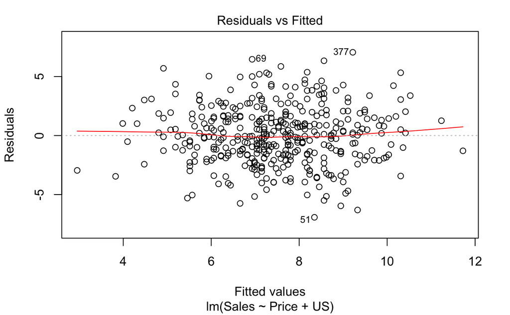

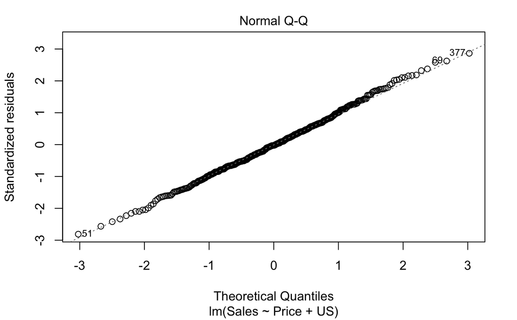

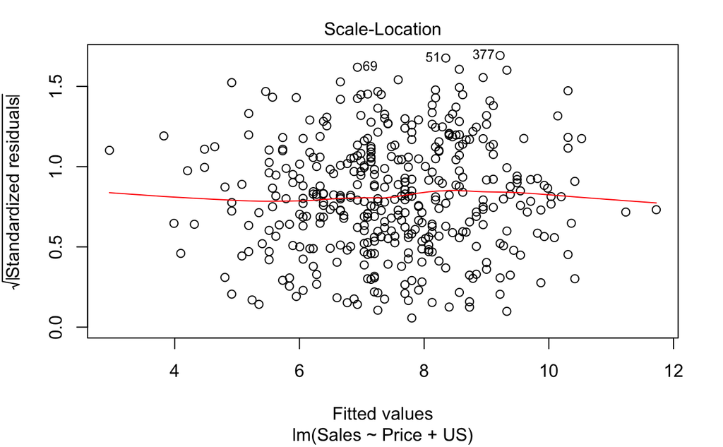

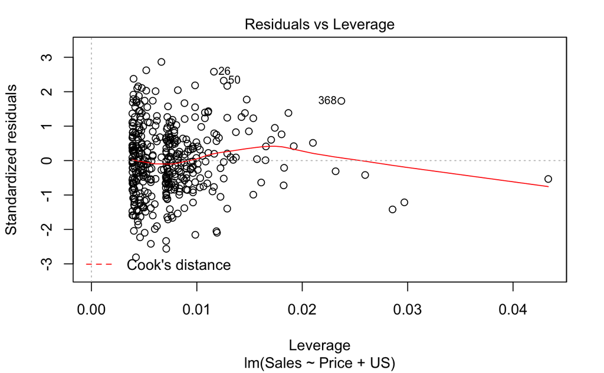

```r
plot(mod4)
```

There are some small outliers but nothing dramatic in terms of leverage, at least marked by the plot. Although one could exclude the highest point on the right part of the plot just to confirm.

```r
set.seed(1)
x <- rnorm(100)
y <- 2 * x + rnorm(100)
```

```r
mod5 <- lm(y ~ x - 1)
summary(mod5)$coef
```

```
  Estimate Std. Error  t value     Pr(>|t|)
x 1.993876  0.1064767 18.72593 2.642197e-34
```

It seems that the estimated increase is different from zero because the standard error `0.11 * 1.96 == 0.21` and that `+/-` 2.1 doesn’t include a zero.

```r
mod6 <- lm(x ~ y - 1)
summary(mod6)$coef
```

```
   Estimate Std. Error  t value     Pr(>|t|)
y 0.3911145 0.02088625 18.72593 2.642197e-34
```

Same t statistic and p value but different estimate and standard error.

3. The estimates and therefore the SE’s are different because substantively you’re predicting another thing. But in terms of significance the relationship being tested is exactly the same; whether on predicts or not the other.

```r
(sqrt(length(y) - 1)) * sum(x * y) / sqrt(sum(x^2) * sum(y^2) - sum(x * y)^2) # is the same as:
```

```
[1] 18.72593
```

```r
summary(mod6)$coef[, 3]
```

```
[1] 18.72593
```

5. Every calculation done in (d) is either addition or multiplication involving x and y. If you swap the places, the result is not changed, so the t value is the same for both.

```r
summary(lm(y ~ x))$coef[ , 3, drop = F]
```

```
               t value
(Intercept) -0.3886346
x           18.5555993
```

```r
summary(lm(x ~ y))$coef[ , 3, drop = F]
```

```
               t value
(Intercept)  0.9095787
y           18.5555993
```

```r
# Exactly the same.
```

The condition happens whe the sum of squares of x and y are equal. In other terms, when both variables are exactly the same, in terms of addition.

```r
x <- rnorm(100)
y <- rnorm(100)
coef(lm(y ~ x))
```

```
(Intercept)           x
 0.04844998  0.10621848
```

```r
coef(lm(x ~ y))
```

```
(Intercept)           y
 0.02371155  0.11553812
```

```r
x <- rnorm(100)
y <- -sample(x, 100)
coef(lm(y ~ x - 1))
```

```
       x
0.148086
```

```r
coef(lm(x ~ y - 1))
```

```
       y
0.148086
```

```r
set.seed(1)
x <- rnorm(100)
```

```r
eps <- rnorm(100, 0, 0.25)
```

```r
y <- -1 + 0.5*x + eps
length(y)
```

```
[1] 100
```

```r
# b0 = -1 and b1 == 0.5
```

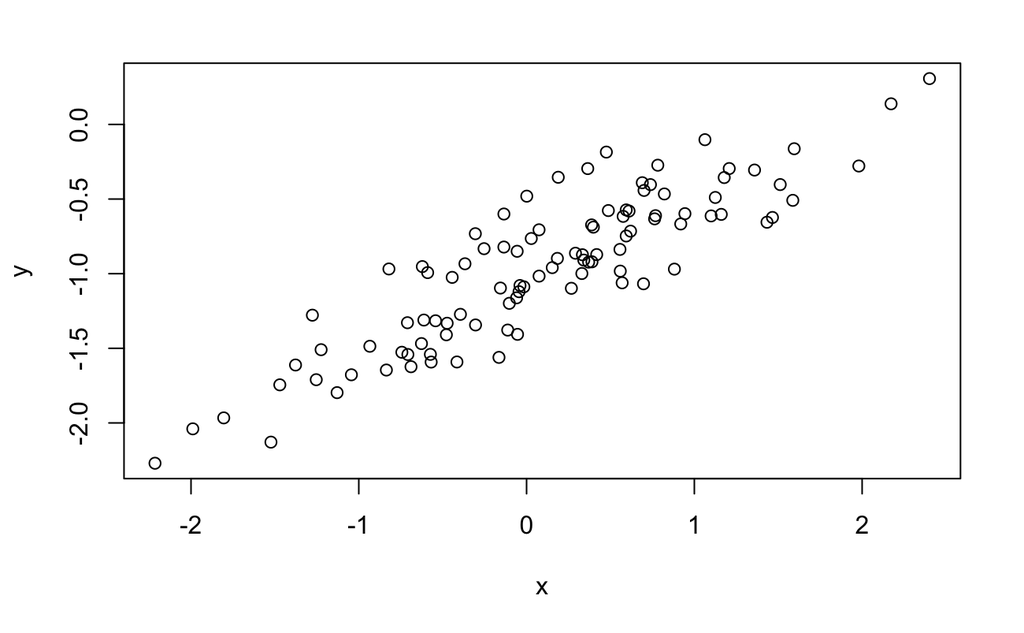

```r
plot(x, y)
```

There’sa fairly linear relationship, as it would be expected from the formula of y.

```r
mod1 <- lm(y ~ x)
summary(mod1)
```

```
Call:
lm(formula = y ~ x)

Residuals:
     Min       1Q   Median       3Q      Max
-0.46921 -0.15344 -0.03487  0.13485  0.58654

Coefficients:
            Estimate Std. Error t value Pr(>|t|)
(Intercept) -1.00942    0.02425  -41.63   <2e-16 ***
x            0.49973    0.02693   18.56   <2e-16 ***
---
Signif. codes:  0 ‘***’ 0.001 ‘**’ 0.01 ‘*’ 0.05 ‘.’ 0.1 ‘ ’ 1

Residual standard error: 0.2407 on 98 degrees of freedom
Multiple R-squared:  0.7784,    Adjusted R-squared:  0.7762
F-statistic: 344.3 on 1 and 98 DF,  p-value: < 2.2e-16
```

The coefficients are practically the same. In fact a difference between the two would be probably be insignificant.

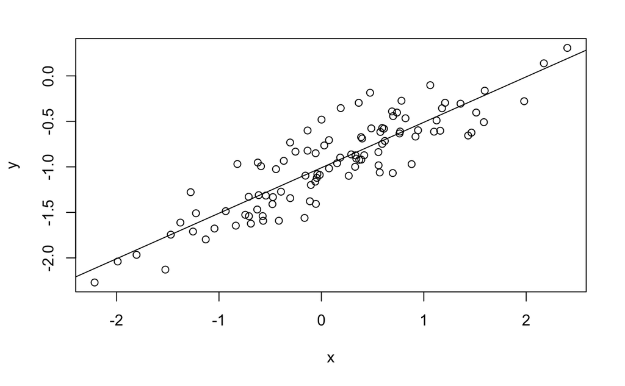

```r
plot(x, y)
abline(lm(y ~ x))
```

```r
summary(lm(y ~ poly(x, 2)))
```

```
Call:
lm(formula = y ~ poly(x, 2))

Residuals:
    Min      1Q  Median      3Q     Max
-0.4913 -0.1563 -0.0322  0.1451  0.5675

Coefficients:
            Estimate Std. Error t value Pr(>|t|)
(Intercept) -0.95501    0.02395 -39.874   <2e-16 ***
poly(x, 2)1  4.46612    0.23951  18.647   <2e-16 ***
poly(x, 2)2 -0.33602    0.23951  -1.403    0.164
---
Signif. codes:  0 ‘***’ 0.001 ‘**’ 0.01 ‘*’ 0.05 ‘.’ 0.1 ‘ ’ 1

Residual standard error: 0.2395 on 97 degrees of freedom
Multiple R-squared:  0.7828,    Adjusted R-squared:  0.7784
F-statistic: 174.8 on 2 and 97 DF,  p-value: < 2.2e-16
```

The adjusted R2 slightly increased and the RSE slightly decreased meaning that the term improved the model. Despite this, the term is insignificant.

```r
set.seed(1)
x <- rnorm(100)
eps <- rnorm(100, 0, 0.12)
y <- -1 + 0.5*x + eps
mod2 <- lm(y ~ x)
summary(mod2)
```

```
Call:
lm(formula = y ~ x)

Residuals:
     Min       1Q   Median       3Q      Max
-0.22522 -0.07365 -0.01674  0.06473  0.28154

Coefficients:
            Estimate Std. Error t value Pr(>|t|)
(Intercept) -1.00452    0.01164  -86.31   <2e-16 ***
x            0.49987    0.01293   38.67   <2e-16 ***
---
Signif. codes:  0 ‘***’ 0.001 ‘**’ 0.01 ‘*’ 0.05 ‘.’ 0.1 ‘ ’ 1

Residual standard error: 0.1155 on 98 degrees of freedom
Multiple R-squared:  0.9385,    Adjusted R-squared:  0.9379
F-statistic:  1495 on 1 and 98 DF,  p-value: < 2.2e-16
```

```r
set.seed(1)
x <- rnorm(100)
eps <- rnorm(100, 0, 0.50)
y <- -1 + 0.5*x + eps
mod3 <- lm(y ~ x)
summary(mod3)
```

```
Call:
lm(formula = y ~ x)

Residuals:
     Min       1Q   Median       3Q      Max
-0.93842 -0.30688 -0.06975  0.26970  1.17309

Coefficients:
            Estimate Std. Error t value Pr(>|t|)
(Intercept) -1.01885    0.04849 -21.010  < 2e-16 ***
x            0.49947    0.05386   9.273 4.58e-15 ***
---
Signif. codes:  0 ‘***’ 0.001 ‘**’ 0.01 ‘*’ 0.05 ‘.’ 0.1 ‘ ’ 1

Residual standard error: 0.4814 on 98 degrees of freedom
Multiple R-squared:  0.4674,    Adjusted R-squared:  0.4619
F-statistic: 85.99 on 1 and 98 DF,  p-value: 4.583e-15
```

The same model with more variation naturally has less explained variance. The adjusted R2 is smaller and the RSE is higher.

```r
confint(mod1)
```

```
                 2.5 %     97.5 %
(Intercept) -1.0575402 -0.9613061
x            0.4462897  0.5531801
```

```r
confint(mod2)
```

```
                 2.5 %     97.5 %
(Intercept) -1.0276193 -0.9814269
x            0.4742191  0.5255264
```

```r
confint(mod3)
```

```
                 2.5 %     97.5 %
(Intercept) -1.1150804 -0.9226122
x            0.3925794  0.6063602
```

The second model, the one with the less unexplained variance, has the smallest CI’s, followed the by the third model, the one with the highest variance unexplained, with the biggest CI’s. For the first model the size of the CI’s are in between the 2nd and 3rd model. Everything as expected.

```r
set.seed(1)
x1 <- runif(100)
x2 <- 0.5 * x1 + rnorm(100)/100
y <- 2 + 2 * x1 + 0.3 * x2 + rnorm(100, sd = 1)
coef(lm(y ~ x1 + x2))
```

```
(Intercept)          x1          x2
   2.130500   -1.753978    7.396742
```

The coefficients are b0 = 2.1 (similar yo the 2 in the function form), b1 = -1.75(far away from the 2 in the functional form) and b2 = 7.39(highly overestimated from the 0.3 in the functional form)

```r
cor(x1, x2)
```

```
[1] 0.9975904
```

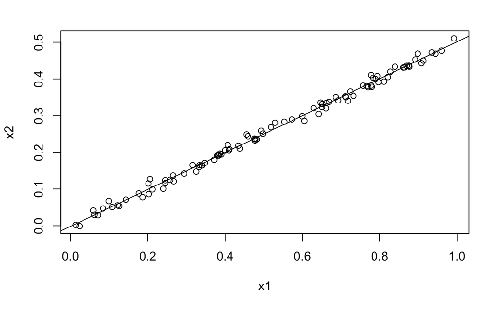

```r
plot(x1, x2)
abline(lm(x2 ~ x1))
```

```r
summary(lm(y ~ x1 + x2))
```

```
Call:
lm(formula = y ~ x1 + x2)

Residuals:
    Min      1Q  Median      3Q     Max
-2.8311 -0.7273 -0.0537  0.6338  2.3359

Coefficients:
            Estimate Std. Error t value Pr(>|t|)
(Intercept)   2.1305     0.2319   9.188 7.61e-15 ***
x1           -1.7540     5.7178  -0.307    0.760
x2            7.3967    11.3372   0.652    0.516
---
Signif. codes:  0 ‘***’ 0.001 ‘**’ 0.01 ‘*’ 0.05 ‘.’ 0.1 ‘ ’ 1

Residual standard error: 1.056 on 97 degrees of freedom
Multiple R-squared:  0.2051,    Adjusted R-squared:  0.1887
F-statistic: 12.51 on 2 and 97 DF,  p-value: 1.465e-05
```

These coefficients are pretty far from the true coefficients. One telling thing from the output is that both coefficients have a reasonable size but their SE’s are huge. This means that both coefficients are insignificantly different from 0.

```r
summary(lm(y ~ x1))
```

```
Call:
lm(formula = y ~ x1)

Residuals:
     Min       1Q   Median       3Q      Max
-2.87789 -0.68357 -0.07517  0.61429  2.40388

Coefficients:
            Estimate Std. Error t value Pr(>|t|)
(Intercept)   2.1172     0.2303   9.193 6.83e-15 ***
x1            1.9675     0.3955   4.974 2.79e-06 ***
---
Signif. codes:  0 ‘***’ 0.001 ‘**’ 0.01 ‘*’ 0.05 ‘.’ 0.1 ‘ ’ 1

Residual standard error: 1.053 on 98 degrees of freedom
Multiple R-squared:  0.2016,    Adjusted R-squared:  0.1934
F-statistic: 24.74 on 1 and 98 DF,  p-value: 2.795e-06
```

The results are highly significant and pretty close to the true coefficient

```r
summary(lm(y ~ x2))
```

```
Call:
lm(formula = y ~ x2)

Residuals:
     Min       1Q   Median       3Q      Max
-2.85470 -0.68465 -0.06898  0.60983  2.34499

Coefficients:
            Estimate Std. Error t value Pr(>|t|)
(Intercept)   2.1199     0.2282   9.288 4.24e-15 ***
x2            3.9273     0.7829   5.016 2.35e-06 ***
---
Signif. codes:  0 ‘***’ 0.001 ‘**’ 0.01 ‘*’ 0.05 ‘.’ 0.1 ‘ ’ 1

Residual standard error: 1.051 on 98 degrees of freedom
Multiple R-squared:  0.2043,    Adjusted R-squared:  0.1962
F-statistic: 25.16 on 1 and 98 DF,  p-value: 2.35e-06
```

This one the coefficient is highly overestimated but it’s still significant.

6. The results do contradict each other because separetely they are significant but when pooled together insignificant. This contradiction is a clue in understanding that there’s something the is increasing their standard errors.

```r
x1 <- c(x1, 0.1)
x2 <- c(x2, 0.8)
y <- c(y, 6)
summary(lm(y ~ x1 +  x2))
```

```
Call:
lm(formula = y ~ x1 + x2)

Residuals:
     Min       1Q   Median       3Q      Max
-2.84668 -0.67731 -0.05031  0.58942  2.34440

Coefficients:
            Estimate Std. Error t value Pr(>|t|)
(Intercept)   2.1250     0.2294   9.265 4.77e-15 ***
x1           -0.5183     0.7578  -0.684 0.495630
x2            4.9440     1.4114   3.503 0.000695 ***
---
Signif. codes:  0 ‘***’ 0.001 ‘**’ 0.01 ‘*’ 0.05 ‘.’ 0.1 ‘ ’ 1

Residual standard error: 1.051 on 98 degrees of freedom
Multiple R-squared:  0.2495,    Adjusted R-squared:  0.2341
F-statistic: 16.29 on 2 and 98 DF,  p-value: 7.82e-07
```

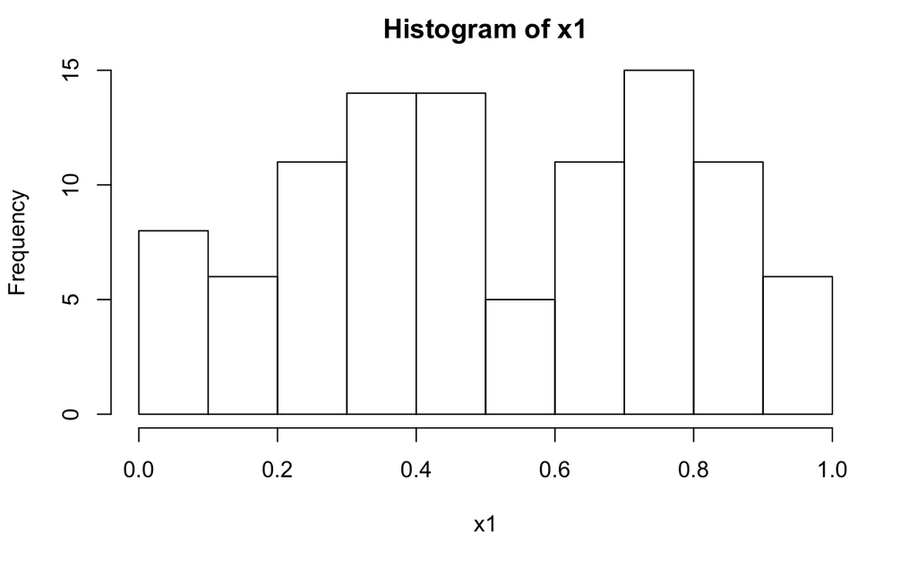

```r
hist(x1)
```

15. (a).

```r
Boston$chas <- factor(Boston$chas, labels = c("N","Y"))
attach(Boston)
lm.zn = lm(crim~zn)
summary(lm.zn) # sign
```

```
Call:
lm(formula = crim ~ zn)

Residuals:
   Min     1Q Median     3Q    Max
-4.429 -4.222 -2.620  1.250 84.523

Coefficients:
            Estimate Std. Error t value Pr(>|t|)
(Intercept)  4.45369    0.41722  10.675  < 2e-16 ***
zn          -0.07393    0.01609  -4.594 5.51e-06 ***
---
Signif. codes:  0 ‘***’ 0.001 ‘**’ 0.01 ‘*’ 0.05 ‘.’ 0.1 ‘ ’ 1

Residual standard error: 8.435 on 504 degrees of freedom
Multiple R-squared:  0.04019,   Adjusted R-squared:  0.03828
F-statistic:  21.1 on 1 and 504 DF,  p-value: 5.506e-06
```

```r
lm.indus = lm(crim~indus)
summary(lm.indus) # sign
```

```
Call:
lm(formula = crim ~ indus)

Residuals:
    Min      1Q  Median      3Q     Max
-11.972  -2.698  -0.736   0.712  81.813

Coefficients:
            Estimate Std. Error t value Pr(>|t|)
(Intercept) -2.06374    0.66723  -3.093  0.00209 **
indus        0.50978    0.05102   9.991  < 2e-16 ***
---
Signif. codes:  0 ‘***’ 0.001 ‘**’ 0.01 ‘*’ 0.05 ‘.’ 0.1 ‘ ’ 1

Residual standard error: 7.866 on 504 degrees of freedom
Multiple R-squared:  0.1653,    Adjusted R-squared:  0.1637
F-statistic: 99.82 on 1 and 504 DF,  p-value: < 2.2e-16
```

```r
lm.chas = lm(crim~chas)
summary(lm.chas) # not sign
```

```
Call:
lm(formula = crim ~ chas)

Residuals:
   Min     1Q Median     3Q    Max
-3.738 -3.661 -3.435  0.018 85.232

Coefficients:
            Estimate Std. Error t value Pr(>|t|)
(Intercept)   3.7444     0.3961   9.453   <2e-16 ***
chasY        -1.8928     1.5061  -1.257    0.209
---
Signif. codes:  0 ‘***’ 0.001 ‘**’ 0.01 ‘*’ 0.05 ‘.’ 0.1 ‘ ’ 1

Residual standard error: 8.597 on 504 degrees of freedom
Multiple R-squared:  0.003124,  Adjusted R-squared:  0.001146
F-statistic: 1.579 on 1 and 504 DF,  p-value: 0.2094
```

```r
lm.nox = lm(crim~nox)
summary(lm.nox) # sign
```

```
Call:
lm(formula = crim ~ nox)

Residuals:
    Min      1Q  Median      3Q     Max
-12.371  -2.738  -0.974   0.559  81.728

Coefficients:
            Estimate Std. Error t value Pr(>|t|)
(Intercept)  -13.720      1.699  -8.073 5.08e-15 ***
nox           31.249      2.999  10.419  < 2e-16 ***
---
Signif. codes:  0 ‘***’ 0.001 ‘**’ 0.01 ‘*’ 0.05 ‘.’ 0.1 ‘ ’ 1

Residual standard error: 7.81 on 504 degrees of freedom
Multiple R-squared:  0.1772,    Adjusted R-squared:  0.1756
F-statistic: 108.6 on 1 and 504 DF,  p-value: < 2.2e-16
```

```r
lm.rm = lm(crim~rm)
summary(lm.rm) # sign
```

```
Call:
lm(formula = crim ~ rm)

Residuals:
   Min     1Q Median     3Q    Max
-6.604 -3.952 -2.654  0.989 87.197

Coefficients:
            Estimate Std. Error t value Pr(>|t|)
(Intercept)   20.482      3.365   6.088 2.27e-09 ***
rm            -2.684      0.532  -5.045 6.35e-07 ***
---
Signif. codes:  0 ‘***’ 0.001 ‘**’ 0.01 ‘*’ 0.05 ‘.’ 0.1 ‘ ’ 1

Residual standard error: 8.401 on 504 degrees of freedom
Multiple R-squared:  0.04807,   Adjusted R-squared:  0.04618
F-statistic: 25.45 on 1 and 504 DF,  p-value: 6.347e-07
```

```r
lm.age = lm(crim~age)
summary(lm.age) # sign
```

```
Call:
lm(formula = crim ~ age)

Residuals:
   Min     1Q Median     3Q    Max
-6.789 -4.257 -1.230  1.527 82.849

Coefficients:
            Estimate Std. Error t value Pr(>|t|)
(Intercept) -3.77791    0.94398  -4.002 7.22e-05 ***
age          0.10779    0.01274   8.463 2.85e-16 ***
---
Signif. codes:  0 ‘***’ 0.001 ‘**’ 0.01 ‘*’ 0.05 ‘.’ 0.1 ‘ ’ 1

Residual standard error: 8.057 on 504 degrees of freedom
Multiple R-squared:  0.1244,    Adjusted R-squared:  0.1227
F-statistic: 71.62 on 1 and 504 DF,  p-value: 2.855e-16
```

```r
lm.dis = lm(crim~dis)
summary(lm.dis) # sign
```

```
Call:
lm(formula = crim ~ dis)

Residuals:
   Min     1Q Median     3Q    Max
-6.708 -4.134 -1.527  1.516 81.674

Coefficients:
            Estimate Std. Error t value Pr(>|t|)
(Intercept)   9.4993     0.7304  13.006   <2e-16 ***
dis          -1.5509     0.1683  -9.213   <2e-16 ***
---
Signif. codes:  0 ‘***’ 0.001 ‘**’ 0.01 ‘*’ 0.05 ‘.’ 0.1 ‘ ’ 1

Residual standard error: 7.965 on 504 degrees of freedom
Multiple R-squared:  0.1441,    Adjusted R-squared:  0.1425
F-statistic: 84.89 on 1 and 504 DF,  p-value: < 2.2e-16
```

```r
lm.rad = lm(crim~rad)
summary(lm.rad) # sign
```

```
Call:
lm(formula = crim ~ rad)

Residuals:
    Min      1Q  Median      3Q     Max
-10.164  -1.381  -0.141   0.660  76.433

Coefficients:
            Estimate Std. Error t value Pr(>|t|)
(Intercept) -2.28716    0.44348  -5.157 3.61e-07 ***
rad          0.61791    0.03433  17.998  < 2e-16 ***
---
Signif. codes:  0 ‘***’ 0.001 ‘**’ 0.01 ‘*’ 0.05 ‘.’ 0.1 ‘ ’ 1

Residual standard error: 6.718 on 504 degrees of freedom
Multiple R-squared:  0.3913,    Adjusted R-squared:   0.39
F-statistic: 323.9 on 1 and 504 DF,  p-value: < 2.2e-16
```

```r
lm.tax = lm(crim~tax)
summary(lm.tax) # sign
```

```
Call:
lm(formula = crim ~ tax)

Residuals:
    Min      1Q  Median      3Q     Max
-12.513  -2.738  -0.194   1.065  77.696

Coefficients:
             Estimate Std. Error t value Pr(>|t|)
(Intercept) -8.528369   0.815809  -10.45   <2e-16 ***
tax          0.029742   0.001847   16.10   <2e-16 ***
---
Signif. codes:  0 ‘***’ 0.001 ‘**’ 0.01 ‘*’ 0.05 ‘.’ 0.1 ‘ ’ 1

Residual standard error: 6.997 on 504 degrees of freedom
Multiple R-squared:  0.3396,    Adjusted R-squared:  0.3383
F-statistic: 259.2 on 1 and 504 DF,  p-value: < 2.2e-16
```

```r
lm.ptratio = lm(crim~ptratio)
summary(lm.ptratio) # sign
```

```
Call:
lm(formula = crim ~ ptratio)

Residuals:
   Min     1Q Median     3Q    Max
-7.654 -3.985 -1.912  1.825 83.353

Coefficients:
            Estimate Std. Error t value Pr(>|t|)
(Intercept) -17.6469     3.1473  -5.607 3.40e-08 ***
ptratio       1.1520     0.1694   6.801 2.94e-11 ***
---
Signif. codes:  0 ‘***’ 0.001 ‘**’ 0.01 ‘*’ 0.05 ‘.’ 0.1 ‘ ’ 1

Residual standard error: 8.24 on 504 degrees of freedom
Multiple R-squared:  0.08407,   Adjusted R-squared:  0.08225
F-statistic: 46.26 on 1 and 504 DF,  p-value: 2.943e-11
```

```r
lm.black = lm(crim~black)
summary(lm.black) # sign
```

```
Call:
lm(formula = crim ~ black)

Residuals:
    Min      1Q  Median      3Q     Max
-13.756  -2.299  -2.095  -1.296  86.822

Coefficients:
             Estimate Std. Error t value Pr(>|t|)
(Intercept) 16.553529   1.425903  11.609   <2e-16 ***
black       -0.036280   0.003873  -9.367   <2e-16 ***
---
Signif. codes:  0 ‘***’ 0.001 ‘**’ 0.01 ‘*’ 0.05 ‘.’ 0.1 ‘ ’ 1

Residual standard error: 7.946 on 504 degrees of freedom
Multiple R-squared:  0.1483,    Adjusted R-squared:  0.1466
F-statistic: 87.74 on 1 and 504 DF,  p-value: < 2.2e-16
```

```r
lm.lstat = lm(crim~lstat)
summary(lm.lstat) # sign
```

```
Call:
lm(formula = crim ~ lstat)

Residuals:
    Min      1Q  Median      3Q     Max
-13.925  -2.822  -0.664   1.079  82.862

Coefficients:
            Estimate Std. Error t value Pr(>|t|)
(Intercept) -3.33054    0.69376  -4.801 2.09e-06 ***
lstat        0.54880    0.04776  11.491  < 2e-16 ***
---
Signif. codes:  0 ‘***’ 0.001 ‘**’ 0.01 ‘*’ 0.05 ‘.’ 0.1 ‘ ’ 1

Residual standard error: 7.664 on 504 degrees of freedom
Multiple R-squared:  0.2076,    Adjusted R-squared:  0.206
F-statistic:   132 on 1 and 504 DF,  p-value: < 2.2e-16
```

```r
lm.medv = lm(crim~medv)
summary(lm.medv) # sign
```

```
Call:
lm(formula = crim ~ medv)

Residuals:
   Min     1Q Median     3Q    Max
-9.071 -4.022 -2.343  1.298 80.957

Coefficients:
            Estimate Std. Error t value Pr(>|t|)
(Intercept) 11.79654    0.93419   12.63   <2e-16 ***
medv        -0.36316    0.03839   -9.46   <2e-16 ***
---
Signif. codes:  0 ‘***’ 0.001 ‘**’ 0.01 ‘*’ 0.05 ‘.’ 0.1 ‘ ’ 1

Residual standard error: 7.934 on 504 degrees of freedom
Multiple R-squared:  0.1508,    Adjusted R-squared:  0.1491
F-statistic: 89.49 on 1 and 504 DF,  p-value: < 2.2e-16
```

```r
detach(Boston)
```

```r
lm.all <- lm(crim ~ ., data = Boston)
summary(lm.all)
```

```
Call:
lm(formula = crim ~ ., data = Boston)

Residuals:
   Min     1Q Median     3Q    Max
-9.924 -2.120 -0.353  1.019 75.051

Coefficients:
              Estimate Std. Error t value Pr(>|t|)
(Intercept)  17.033228   7.234903   2.354 0.018949 *
zn            0.044855   0.018734   2.394 0.017025 *
indus        -0.063855   0.083407  -0.766 0.444294
chasY        -0.749134   1.180147  -0.635 0.525867
nox         -10.313535   5.275536  -1.955 0.051152 .
rm            0.430131   0.612830   0.702 0.483089
age           0.001452   0.017925   0.081 0.935488
dis          -0.987176   0.281817  -3.503 0.000502 ***
rad           0.588209   0.088049   6.680 6.46e-11 ***
tax          -0.003780   0.005156  -0.733 0.463793
ptratio      -0.271081   0.186450  -1.454 0.146611
black        -0.007538   0.003673  -2.052 0.040702 *
lstat         0.126211   0.075725   1.667 0.096208 .
medv         -0.198887   0.060516  -3.287 0.001087 **
---
Signif. codes:  0 ‘***’ 0.001 ‘**’ 0.01 ‘*’ 0.05 ‘.’ 0.1 ‘ ’ 1

Residual standard error: 6.439 on 492 degrees of freedom
Multiple R-squared:  0.454, Adjusted R-squared:  0.4396
F-statistic: 31.47 on 13 and 492 DF,  p-value: < 2.2e-16
```

Once adjusted for all covariates, zn, dis, rad, black and medv are the only ones significant.

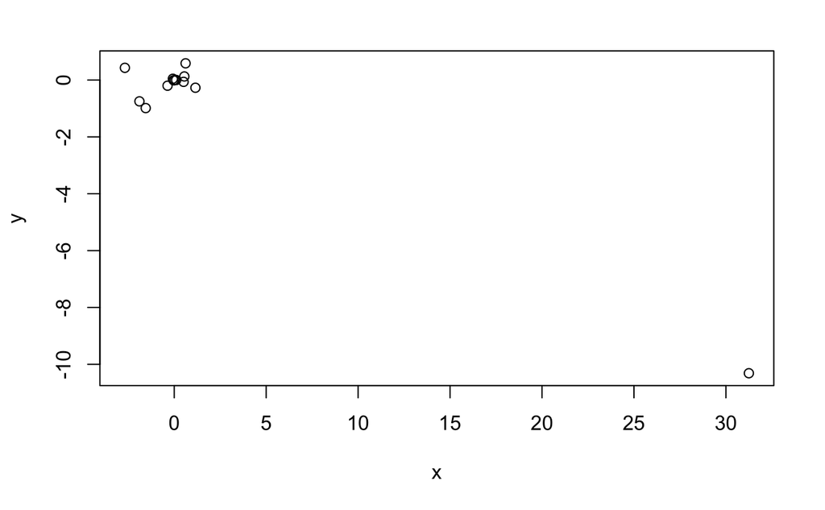

```r
x = c(coefficients(lm.zn)[2],
      coefficients(lm.indus)[2],
      coefficients(lm.chas)[2],
      coefficients(lm.nox)[2],
      coefficients(lm.rm)[2],
      coefficients(lm.age)[2],
      coefficients(lm.dis)[2],
      coefficients(lm.rad)[2],
      coefficients(lm.tax)[2],
      coefficients(lm.ptratio)[2],
      coefficients(lm.black)[2],
      coefficients(lm.lstat)[2],
      coefficients(lm.medv)[2])
y = coefficients(lm.all)[2:14]
plot(x, y)
```

Although there are some changes in the coefficients, only nox had a dramatic change from 31 to -10.

```r
lm.zn = lm(crim~poly(zn,3))
summary(lm.zn) # 1, 2
```

```
Call:
lm(formula = crim ~ poly(zn, 3))

Residuals:
   Min     1Q Median     3Q    Max
-4.821 -4.614 -1.294  0.473 84.130

Coefficients:
             Estimate Std. Error t value Pr(>|t|)
(Intercept)    3.6135     0.3722   9.709  < 2e-16 ***
poly(zn, 3)1 -38.7498     8.3722  -4.628  4.7e-06 ***
poly(zn, 3)2  23.9398     8.3722   2.859  0.00442 **
poly(zn, 3)3 -10.0719     8.3722  -1.203  0.22954
---
Signif. codes:  0 ‘***’ 0.001 ‘**’ 0.01 ‘*’ 0.05 ‘.’ 0.1 ‘ ’ 1

Residual standard error: 8.372 on 502 degrees of freedom
Multiple R-squared:  0.05824,   Adjusted R-squared:  0.05261
F-statistic: 10.35 on 3 and 502 DF,  p-value: 1.281e-06
```

```r
lm.indus = lm(crim~poly(indus,3))
summary(lm.indus) # 1, 2, 3
```

```
Call:
lm(formula = crim ~ poly(indus, 3))

Residuals:
   Min     1Q Median     3Q    Max
-8.278 -2.514  0.054  0.764 79.713

Coefficients:
                Estimate Std. Error t value Pr(>|t|)
(Intercept)        3.614      0.330  10.950  < 2e-16 ***
poly(indus, 3)1   78.591      7.423  10.587  < 2e-16 ***
poly(indus, 3)2  -24.395      7.423  -3.286  0.00109 **
poly(indus, 3)3  -54.130      7.423  -7.292  1.2e-12 ***
---
Signif. codes:  0 ‘***’ 0.001 ‘**’ 0.01 ‘*’ 0.05 ‘.’ 0.1 ‘ ’ 1

Residual standard error: 7.423 on 502 degrees of freedom
Multiple R-squared:  0.2597,    Adjusted R-squared:  0.2552
F-statistic: 58.69 on 3 and 502 DF,  p-value: < 2.2e-16
```

```r
# lm.chas = lm(crim~poly(chas,3)) : qualitative predictor
lm.nox = lm(crim~poly(nox,3))
summary(lm.nox) # 1, 2, 3
```

```
Call:
lm(formula = crim ~ poly(nox, 3))

Residuals:
   Min     1Q Median     3Q    Max
-9.110 -2.068 -0.255  0.739 78.302

Coefficients:
              Estimate Std. Error t value Pr(>|t|)
(Intercept)     3.6135     0.3216  11.237  < 2e-16 ***
poly(nox, 3)1  81.3720     7.2336  11.249  < 2e-16 ***
poly(nox, 3)2 -28.8286     7.2336  -3.985 7.74e-05 ***
poly(nox, 3)3 -60.3619     7.2336  -8.345 6.96e-16 ***
---
Signif. codes:  0 ‘***’ 0.001 ‘**’ 0.01 ‘*’ 0.05 ‘.’ 0.1 ‘ ’ 1

Residual standard error: 7.234 on 502 degrees of freedom
Multiple R-squared:  0.297, Adjusted R-squared:  0.2928
F-statistic: 70.69 on 3 and 502 DF,  p-value: < 2.2e-16
```

```r
lm.rm = lm(crim~poly(rm,3))
summary(lm.rm) # 1, 2
```

```
Call:
lm(formula = crim ~ poly(rm, 3))

Residuals:
    Min      1Q  Median      3Q     Max
-18.485  -3.468  -2.221  -0.015  87.219

Coefficients:
             Estimate Std. Error t value Pr(>|t|)
(Intercept)    3.6135     0.3703   9.758  < 2e-16 ***
poly(rm, 3)1 -42.3794     8.3297  -5.088 5.13e-07 ***
poly(rm, 3)2  26.5768     8.3297   3.191  0.00151 **
poly(rm, 3)3  -5.5103     8.3297  -0.662  0.50858
---
Signif. codes:  0 ‘***’ 0.001 ‘**’ 0.01 ‘*’ 0.05 ‘.’ 0.1 ‘ ’ 1

Residual standard error: 8.33 on 502 degrees of freedom
Multiple R-squared:  0.06779,   Adjusted R-squared:  0.06222
F-statistic: 12.17 on 3 and 502 DF,  p-value: 1.067e-07
```

```r
lm.age = lm(crim~poly(age,3))
summary(lm.age) # 1, 2, 3
```

```
Call:
lm(formula = crim ~ poly(age, 3))

Residuals:
   Min     1Q Median     3Q    Max
-9.762 -2.673 -0.516  0.019 82.842

Coefficients:
              Estimate Std. Error t value Pr(>|t|)
(Intercept)     3.6135     0.3485  10.368  < 2e-16 ***
poly(age, 3)1  68.1820     7.8397   8.697  < 2e-16 ***
poly(age, 3)2  37.4845     7.8397   4.781 2.29e-06 ***
poly(age, 3)3  21.3532     7.8397   2.724  0.00668 **
---
Signif. codes:  0 ‘***’ 0.001 ‘**’ 0.01 ‘*’ 0.05 ‘.’ 0.1 ‘ ’ 1

Residual standard error: 7.84 on 502 degrees of freedom
Multiple R-squared:  0.1742,    Adjusted R-squared:  0.1693
F-statistic: 35.31 on 3 and 502 DF,  p-value: < 2.2e-16
```

```r
lm.dis = lm(crim~poly(dis,3))
summary(lm.dis) # 1, 2, 3
```

```
Call:
lm(formula = crim ~ poly(dis, 3))

Residuals:
    Min      1Q  Median      3Q     Max
-10.757  -2.588   0.031   1.267  76.378

Coefficients:
              Estimate Std. Error t value Pr(>|t|)
(Intercept)     3.6135     0.3259  11.087  < 2e-16 ***
poly(dis, 3)1 -73.3886     7.3315 -10.010  < 2e-16 ***
poly(dis, 3)2  56.3730     7.3315   7.689 7.87e-14 ***
poly(dis, 3)3 -42.6219     7.3315  -5.814 1.09e-08 ***
---
Signif. codes:  0 ‘***’ 0.001 ‘**’ 0.01 ‘*’ 0.05 ‘.’ 0.1 ‘ ’ 1

Residual standard error: 7.331 on 502 degrees of freedom
Multiple R-squared:  0.2778,    Adjusted R-squared:  0.2735
F-statistic: 64.37 on 3 and 502 DF,  p-value: < 2.2e-16
```

```r
lm.rad = lm(crim~poly(rad,3))
summary(lm.rad) # 1, 2
```

```
Call:
lm(formula = crim ~ poly(rad, 3))

Residuals:
    Min      1Q  Median      3Q     Max
-10.381  -0.412  -0.269   0.179  76.217

Coefficients:
              Estimate Std. Error t value Pr(>|t|)
(Intercept)     3.6135     0.2971  12.164  < 2e-16 ***
poly(rad, 3)1 120.9074     6.6824  18.093  < 2e-16 ***
poly(rad, 3)2  17.4923     6.6824   2.618  0.00912 **
poly(rad, 3)3   4.6985     6.6824   0.703  0.48231
---
Signif. codes:  0 ‘***’ 0.001 ‘**’ 0.01 ‘*’ 0.05 ‘.’ 0.1 ‘ ’ 1

Residual standard error: 6.682 on 502 degrees of freedom
Multiple R-squared:    0.4, Adjusted R-squared:  0.3965
F-statistic: 111.6 on 3 and 502 DF,  p-value: < 2.2e-16
```

```r
lm.tax = lm(crim~poly(tax,3))
summary(lm.tax) # 1, 2
```

```
Call:
lm(formula = crim ~ poly(tax, 3))

Residuals:
    Min      1Q  Median      3Q     Max
-13.273  -1.389   0.046   0.536  76.950

Coefficients:
              Estimate Std. Error t value Pr(>|t|)
(Intercept)     3.6135     0.3047  11.860  < 2e-16 ***
poly(tax, 3)1 112.6458     6.8537  16.436  < 2e-16 ***
poly(tax, 3)2  32.0873     6.8537   4.682 3.67e-06 ***
poly(tax, 3)3  -7.9968     6.8537  -1.167    0.244
---
Signif. codes:  0 ‘***’ 0.001 ‘**’ 0.01 ‘*’ 0.05 ‘.’ 0.1 ‘ ’ 1

Residual standard error: 6.854 on 502 degrees of freedom
Multiple R-squared:  0.3689,    Adjusted R-squared:  0.3651
F-statistic:  97.8 on 3 and 502 DF,  p-value: < 2.2e-16
```

```r
lm.ptratio = lm(crim~poly(ptratio,3))
summary(lm.ptratio) # 1, 2, 3
```

```
Call:
lm(formula = crim ~ poly(ptratio, 3))

Residuals:
   Min     1Q Median     3Q    Max
-6.833 -4.146 -1.655  1.408 82.697

Coefficients:
                  Estimate Std. Error t value Pr(>|t|)
(Intercept)          3.614      0.361  10.008  < 2e-16 ***
poly(ptratio, 3)1   56.045      8.122   6.901 1.57e-11 ***
poly(ptratio, 3)2   24.775      8.122   3.050  0.00241 **
poly(ptratio, 3)3  -22.280      8.122  -2.743  0.00630 **
---
Signif. codes:  0 ‘***’ 0.001 ‘**’ 0.01 ‘*’ 0.05 ‘.’ 0.1 ‘ ’ 1

Residual standard error: 8.122 on 502 degrees of freedom
Multiple R-squared:  0.1138,    Adjusted R-squared:  0.1085
F-statistic: 21.48 on 3 and 502 DF,  p-value: 4.171e-13
```

```r
lm.black = lm(crim~poly(black,3))
summary(lm.black) # 1
```

```
Call:
lm(formula = crim ~ poly(black, 3))

Residuals:
    Min      1Q  Median      3Q     Max
-13.096  -2.343  -2.128  -1.439  86.790

Coefficients:
                Estimate Std. Error t value Pr(>|t|)
(Intercept)       3.6135     0.3536  10.218   <2e-16 ***
poly(black, 3)1 -74.4312     7.9546  -9.357   <2e-16 ***
poly(black, 3)2   5.9264     7.9546   0.745    0.457
poly(black, 3)3  -4.8346     7.9546  -0.608    0.544
---
Signif. codes:  0 ‘***’ 0.001 ‘**’ 0.01 ‘*’ 0.05 ‘.’ 0.1 ‘ ’ 1

Residual standard error: 7.955 on 502 degrees of freedom
Multiple R-squared:  0.1498,    Adjusted R-squared:  0.1448
F-statistic: 29.49 on 3 and 502 DF,  p-value: < 2.2e-16
```

```r
lm.lstat = lm(crim~poly(lstat,3))
summary(lm.lstat) # 1, 2
```

```
Call:
lm(formula = crim ~ poly(lstat, 3))

Residuals:
    Min      1Q  Median      3Q     Max
-15.234  -2.151  -0.486   0.066  83.353

Coefficients:
                Estimate Std. Error t value Pr(>|t|)
(Intercept)       3.6135     0.3392  10.654   <2e-16 ***
poly(lstat, 3)1  88.0697     7.6294  11.543   <2e-16 ***
poly(lstat, 3)2  15.8882     7.6294   2.082   0.0378 *
poly(lstat, 3)3 -11.5740     7.6294  -1.517   0.1299
---
Signif. codes:  0 ‘***’ 0.001 ‘**’ 0.01 ‘*’ 0.05 ‘.’ 0.1 ‘ ’ 1

Residual standard error: 7.629 on 502 degrees of freedom
Multiple R-squared:  0.2179,    Adjusted R-squared:  0.2133
F-statistic: 46.63 on 3 and 502 DF,  p-value: < 2.2e-16
```

```r
lm.medv = lm(crim~poly(medv,3))
summary(lm.medv) # 1, 2, 3
```

```
Call:
lm(formula = crim ~ poly(medv, 3))

Residuals:
    Min      1Q  Median      3Q     Max
-24.427  -1.976  -0.437   0.439  73.655

Coefficients:
               Estimate Std. Error t value Pr(>|t|)
(Intercept)       3.614      0.292  12.374  < 2e-16 ***
poly(medv, 3)1  -75.058      6.569 -11.426  < 2e-16 ***
poly(medv, 3)2   88.086      6.569  13.409  < 2e-16 ***
poly(medv, 3)3  -48.033      6.569  -7.312 1.05e-12 ***
---
Signif. codes:  0 ‘***’ 0.001 ‘**’ 0.01 ‘*’ 0.05 ‘.’ 0.1 ‘ ’ 1

Residual standard error: 6.569 on 502 degrees of freedom
Multiple R-squared:  0.4202,    Adjusted R-squared:  0.4167
F-statistic: 121.3 on 3 and 502 DF,  p-value: < 2.2e-16
```